# week9assignment_RC

2025-03-18

## Set Up

```r
lizards <- read.csv("jrn_lizard.csv")

library(here)
library(tidyverse)
library(naniar)
library(DHARMa)
library(gtsummary)
library(broom)

lizards_filtered <- lizards %>%
  filter(spp == "UTST")
```

## Exploratory Figures

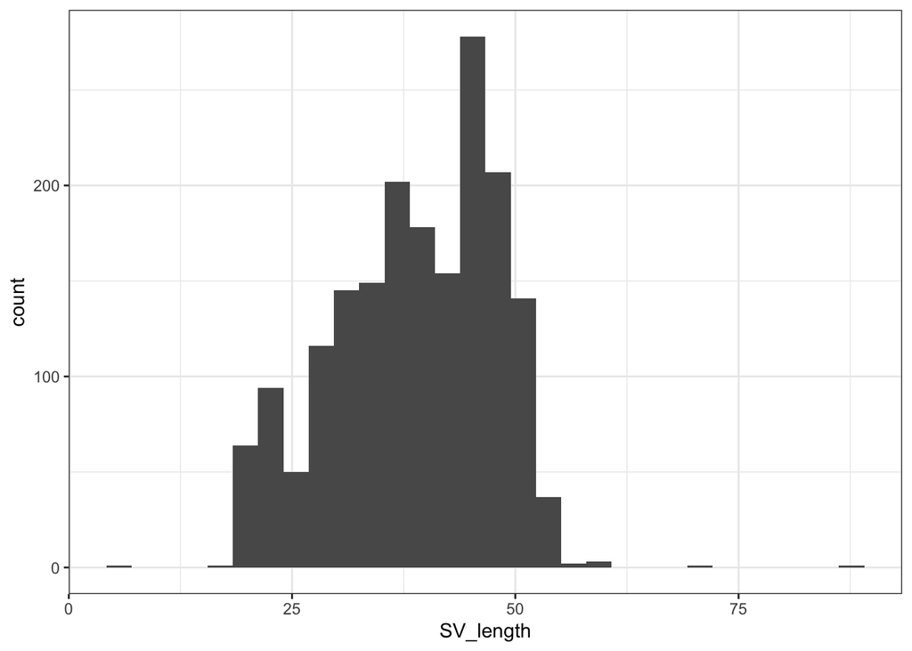

```r
hist1 <- ggplot(lizards_filtered, aes(x = SV_length)) +
  geom_histogram() +
  theme_bw()
hist1
```

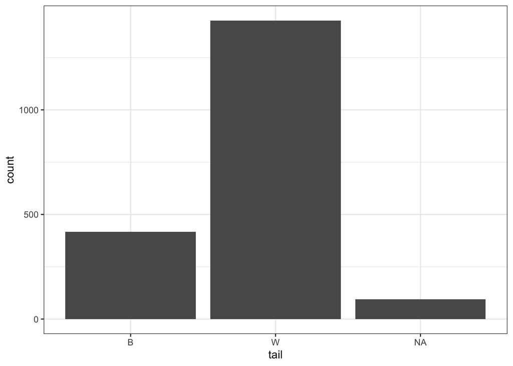

```r
bar1 <- ggplot(lizards_filtered, aes(x = tail)) + #cannot do histogram without continuous x
  geom_bar() +
  theme_bw()
bar1
```

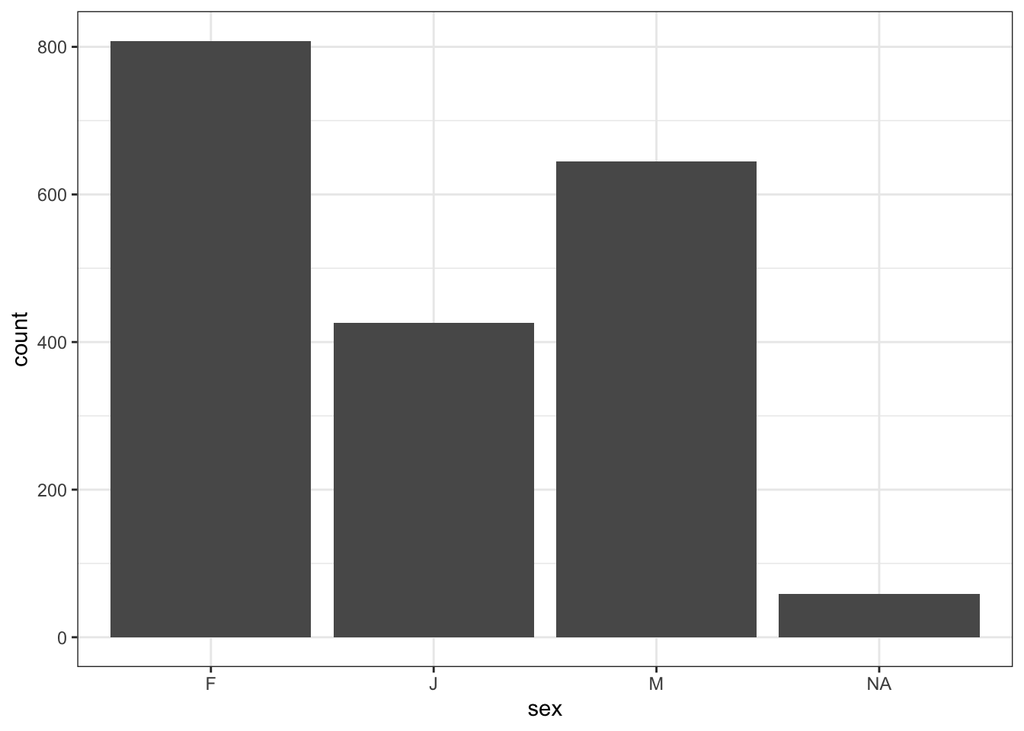

```r
bar2 <- ggplot(lizards_filtered, aes(x = sex)) + geom_bar() + theme_bw()
bar2
```

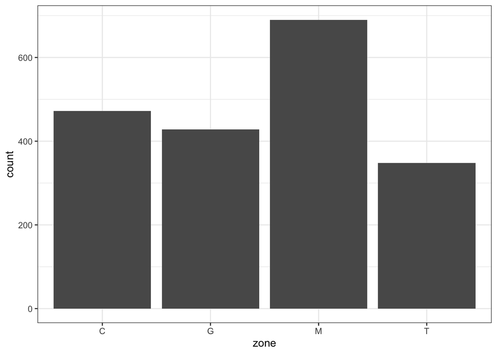

```r
bar3 <- ggplot(lizards_filtered, aes(x = zone)) + geom_bar() + theme_bw()
bar3
```

## As Factors and Model

```r
unique(lizards_filtered$zone)
```

```
## [1] "C" "G" "M" "T"
```

```r
lizards_filtered$zone <- factor(lizards_filtered$zone,
                              levels = c("C", "G", "M", "T"))

unique(lizards_filtered$sex)
```

```
## [1] "J" "F" NA  "M"
```

```r
lizards_filtered$sex <- factor(lizards_filtered$sex,
                              levels = c("J", "F", "M"))

unique(lizards_filtered$tail)
```

```
## [1] "B" "W" NA
```

```r
lizards_filtered$tail <- factor(lizards_filtered$tail,
                              levels = c("B", "W"))

liz_mod <- glm(tail~SV_length+sex+zone,
                 data = lizards_filtered,
                 family = "binomial")

summary(liz_mod)
```

```
##
## Call:
## glm(formula = tail ~ SV_length + sex + zone, family = "binomial",
##     data = lizards_filtered)
##
## Coefficients:
##              Estimate Std. Error z value Pr(>|z|)
## (Intercept)  3.493940   0.332420  10.511  < 2e-16 ***
## SV_length   -0.045230   0.008877  -5.095 3.49e-07 ***
## sexF        -0.203871   0.206033  -0.990  0.32241
## sexM        -0.138956   0.223664  -0.621  0.53442
## zoneG       -0.565369   0.173745  -3.254  0.00114 **
## zoneM       -0.301313   0.162032  -1.860  0.06294 .
## zoneT       -0.404349   0.179938  -2.247  0.02463 *
## ---
## Signif. codes:  0 '***' 0.001 '**' 0.01 '*' 0.05 '.' 0.1 ' ' 1
##
## (Dispersion parameter for binomial family taken to be 1)
##
##     Null deviance: 1931.7  on 1799  degrees of freedom
## Residual deviance: 1867.3  on 1793  degrees of freedom
##   (138 observations deleted due to missingness)
## AIC: 1881.3
##
## Number of Fisher Scoring iterations: 4
```

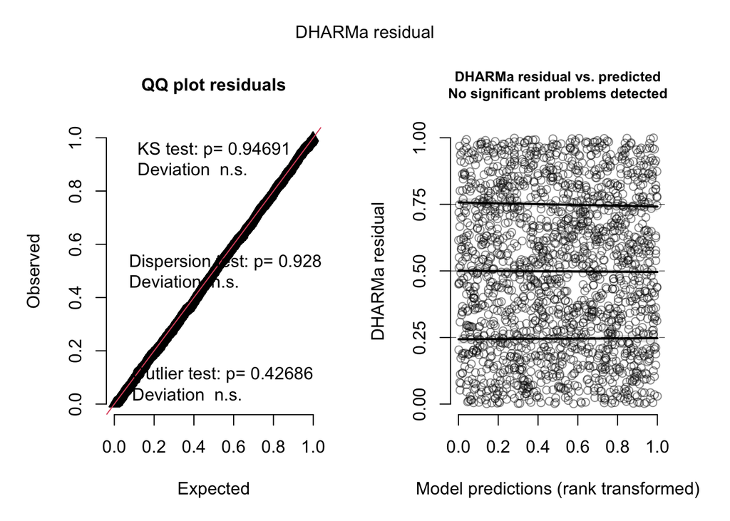

```r
simulateResiduals(liz_mod) %>% plot()
```

The results of a logistic regression suggest that the log-odds of having a whole tail are greater with lower snout-to-vent length (B = -0.045, p < 0.001). There was also a significant decrease in log-odds of having a whole tail in vegetation zones with black grama grassland (B = -0.565, p = 0.001) and tarbush shrubland (B = -0.404, p = 0.025) relative to creosotebush shrubland. Mesquite duneland vegetation zones (B = -0.301, p = 0.063) did not have significant log-odds of having a whole tail relative to creosotebush shrubland. Neither females (B = -0.204, p = 0.322) nor males (B = -0.139, p = 0.534) had significant log-odds of having a whole tail relative to juveniles.

## Predictive Figures

```r
# variables are SV length, sex, and zone

range(lizards_filtered$SV_length, na.rm=TRUE)
```

```
## [1]  5 87
```

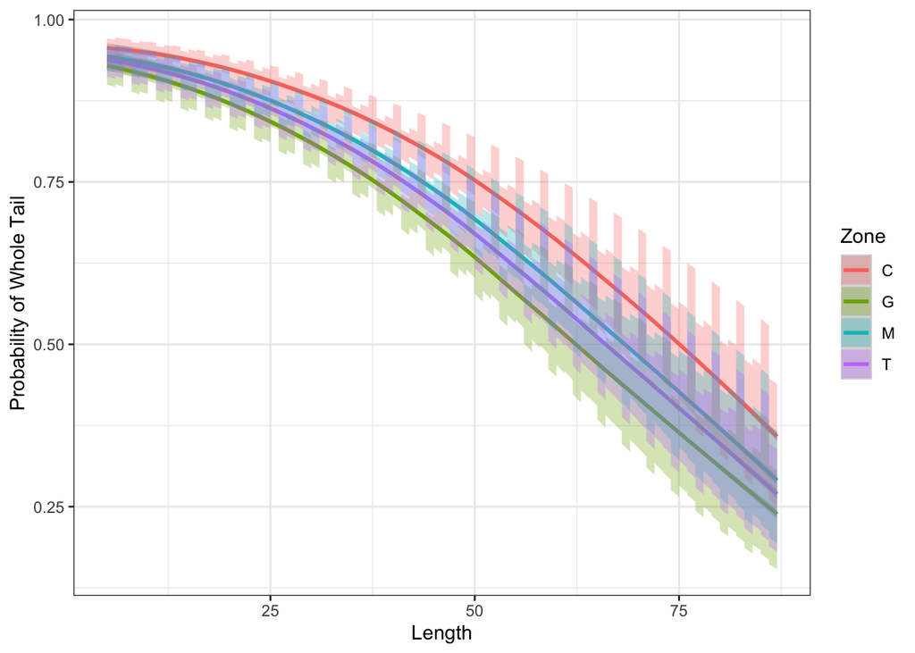

Figure 1. Predictive model of the probability of a lizard tail being whole in relation to snout-to-vent length by vegetation zone.

```r
length_vector <- rep(seq(from = 5, to = 87), 12) #83, 3, and 4 don't have common factors

sex_vector <- rep(c("J", "F", "M"), 332)

zone_vector <- c(rep("C", 249),
                   rep("G", 249),
                 rep("M", 249),
                 rep("T", 249))

data_pred <- data.frame(sex_vector, length_vector, zone_vector)
colnames(data_pred) <- c("sex", "SV_length", "zone")

prediction <- predict(liz_mod,
                      newdata = data_pred,
                      type = "response",
                      se.fit = TRUE)


data_fig <- data.frame(data_pred,
                       prediction$fit,
                       prediction$se.fit)


colnames(data_fig) <- c("Sex", "Length", "Zone", "probability", "se")

ggplot(data_fig, aes(x = Length,
                     y = probability)) +
  geom_smooth(aes(color = Zone)) +
  geom_ribbon(aes(ymin = probability - se,
                  ymax = probability + se,
                  fill = Zone), alpha = 0.3) +
  labs(x = "Length", y = "Probability of Whole Tail", color = "Zone", fill = "Zone") +
  theme_bw()
```

```r
# jagged because there are so many replicates?
```

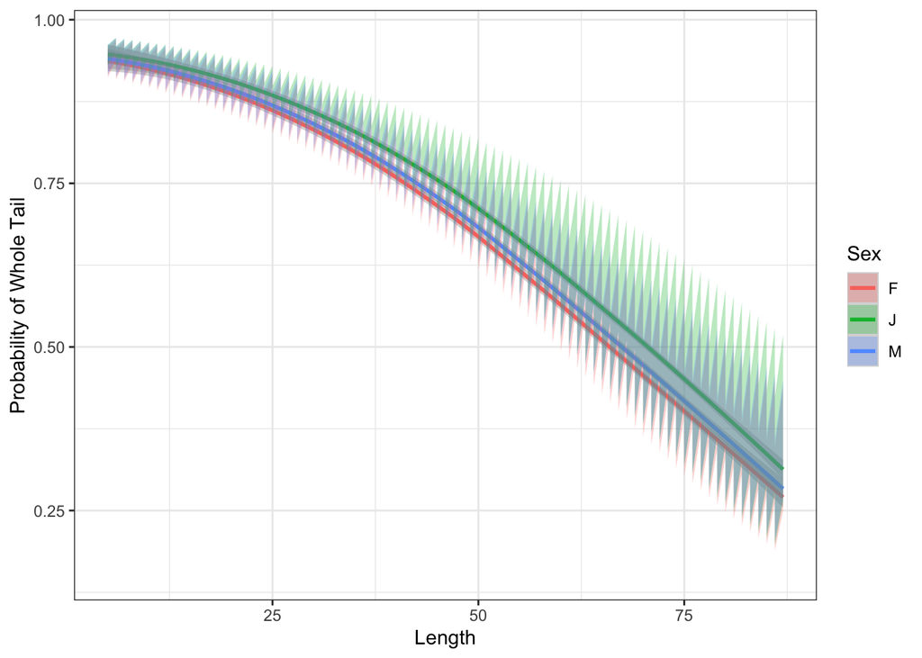

Figure 2. Predictive model of the probability of a lizard tail being whole in relation to snout-to-vent length by sex.

```r
ggplot(data_fig, aes(x = Length,
                     y = probability)) +
  geom_smooth(aes(color = Sex)) +
  geom_ribbon(aes(ymin = probability - se,
                  ymax = probability + se,
                  fill = Sex), alpha = 0.3) +
  labs(x = "Length", y = "Probability of Whole Tail", color = "Sex", fill = "Sex") +
  theme_bw()
```

The probability of having a whole tail decreases as snout-to-vent length increases for all sexes and vegetation zones.

## Poisson Regression: Exploratory Plots

```r
lizards2 <- read_csv("jrn_lizard_npp.csv")
```

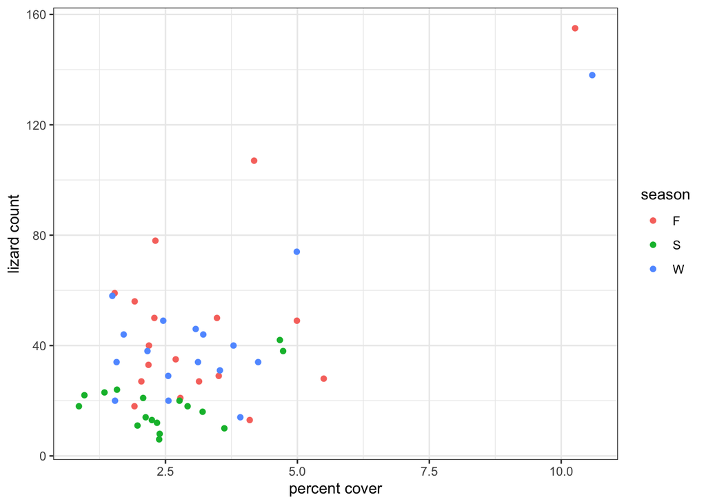

```r
ggplot(lizards2, aes(x = BOER,
                     y = lizard_count)) +
  geom_point(aes(color = season)) +
  labs(x = "percent cover", y = "lizard count") +
  theme_bw()
```

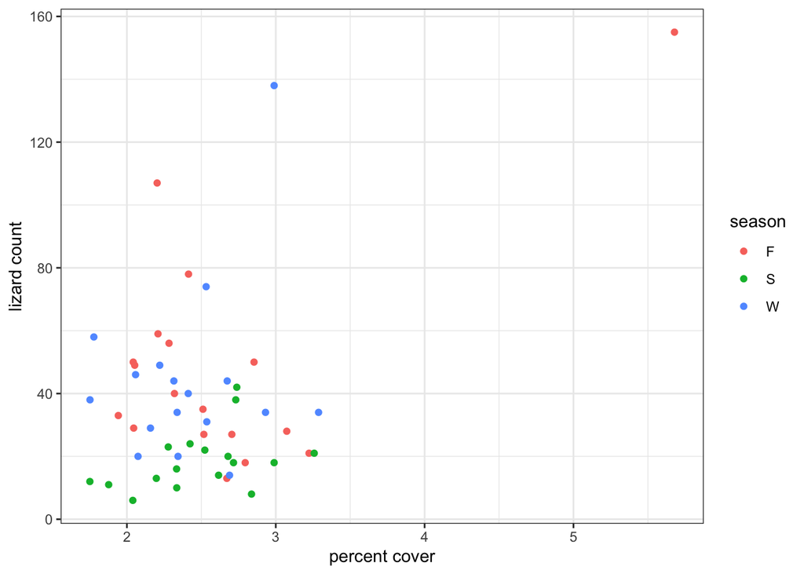

```r
ggplot(lizards2, aes(x = LATR,
                     y = lizard_count)) +
  geom_point(aes(color = season)) +
  labs(x = "percent cover", y = "lizard count") +
  theme_bw()
```

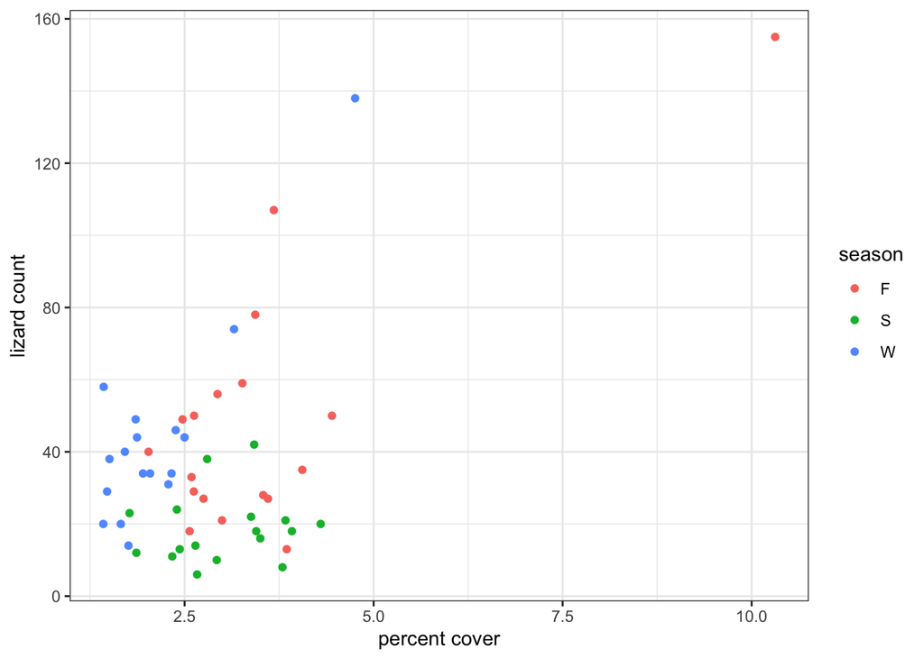

```r
ggplot(lizards2, aes(x = PRGL,
                     y = lizard_count)) +
  geom_point(aes(color = season)) +
  labs(x = "percent cover", y = "lizard count") +
  theme_bw()
```

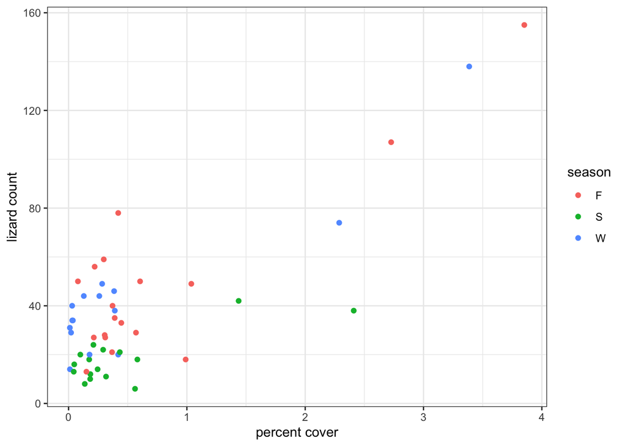

```r
ggplot(lizards2, aes(x = SCBR,
                     y = lizard_count)) +
  geom_point(aes(color = season)) +
  labs(x = "percent cover", y = "lizard count") +
  theme_bw()
```

## Poisson Regression

```r
unique(lizards2$season)
```

```
## [1] "F" "S" "W"
```

```r
lizards2$season <- factor(lizards2$season,
                             levels = c("F",
                                        "S",
                                        "W"))

lizard2_mod <- glm(lizard_count~season+BOER+LATR+PRGL+SCBR,
                data = lizards2,
                family = "poisson")
```

```r
summary(lizard2_mod)
```

```
##
## Call:
## glm(formula = lizard_count ~ season + BOER + LATR + PRGL + SCBR,
##     family = "poisson", data = lizards2)
##
## Coefficients:
##             Estimate Std. Error z value Pr(>|z|)
## (Intercept)  3.76785    0.09880  38.136  < 2e-16 ***
## seasonS     -0.75234    0.06970 -10.795  < 2e-16 ***
## seasonW      0.20278    0.07464   2.717  0.00659 **
## BOER        -0.03260    0.02160  -1.509  0.13120
## LATR        -0.34305    0.07757  -4.423 9.74e-06 ***
## PRGL         0.20656    0.04412   4.681 2.85e-06 ***
## SCBR         0.37960    0.04199   9.040  < 2e-16 ***
## ---
## Signif. codes:  0 '***' 0.001 '**' 0.01 '*' 0.05 '.' 0.1 ' ' 1
##
## (Dispersion parameter for poisson family taken to be 1)
##
##     Null deviance: 911.44  on 48  degrees of freedom
## Residual deviance: 184.19  on 42  degrees of freedom
##   (3 observations deleted due to missingness)
## AIC: 453.85
##
## Number of Fisher Scoring iterations: 4
```

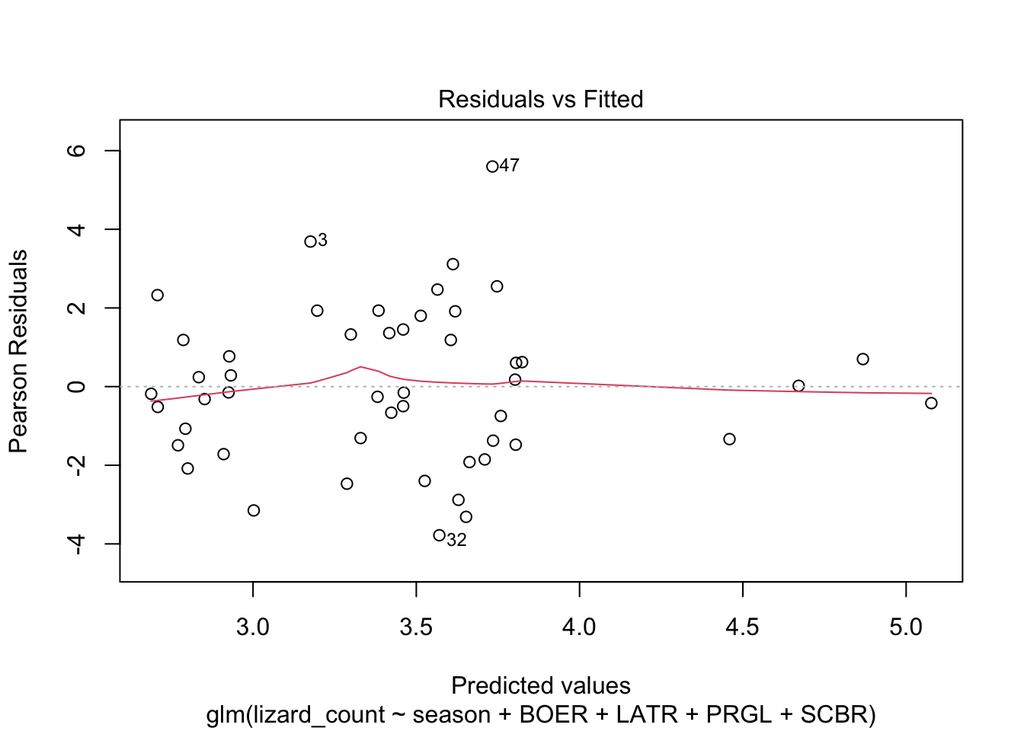

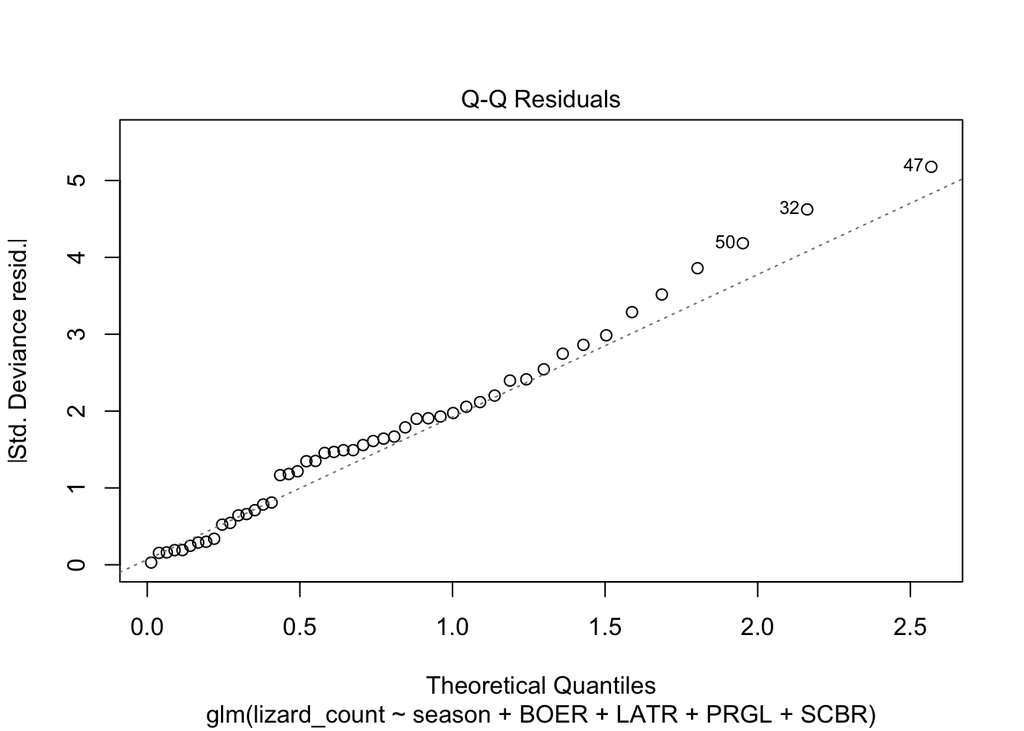

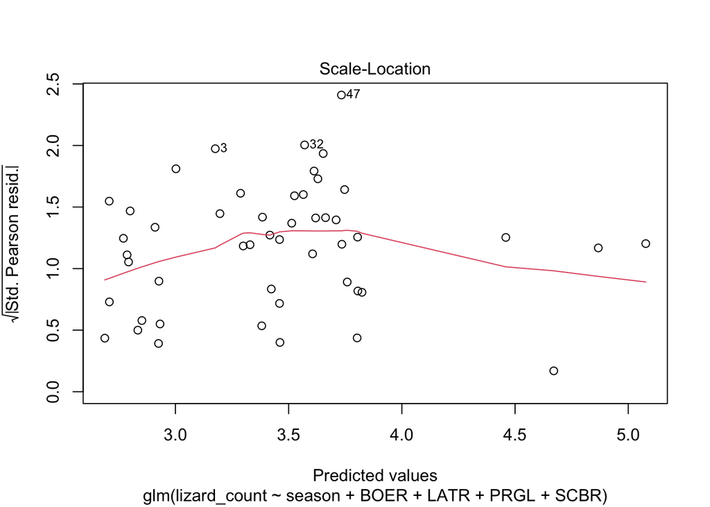

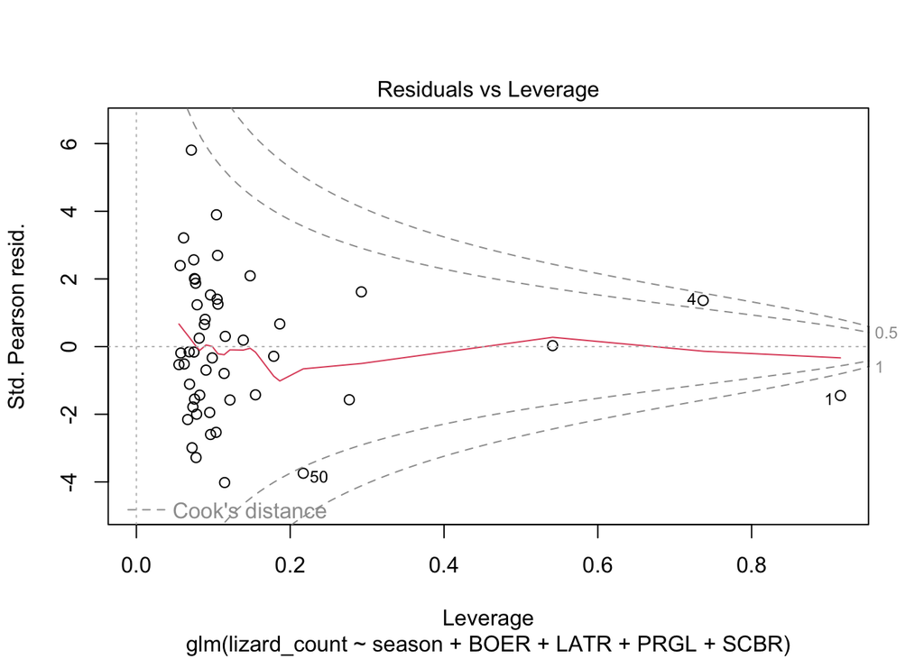

```r
plot(lizard2_mod)
```

```r
lizards2_2 <- lizards2[-c(1,4,50),]

lizard2_mod_2 <- glm(lizard_count~season+BOER+LATR+PRGL+SCBR,
                 data = lizards2_2,
                 family = "poisson")

summary(lizard2_mod_2)
```

```
##
## Call:
## glm(formula = lizard_count ~ season + BOER + LATR + PRGL + SCBR,
##     family = "poisson", data = lizards2_2)
##
## Coefficients:
##             Estimate Std. Error z value Pr(>|z|)
## (Intercept)  3.58137    0.18748  19.102  < 2e-16 ***
## seasonS     -0.84691    0.07277 -11.638  < 2e-16 ***
## seasonW      0.10419    0.08321   1.252  0.21056
## BOER        -0.10478    0.03249  -3.225  0.00126 **
## LATR        -0.10037    0.09565  -1.049  0.29398
## PRGL         0.14701    0.05450   2.697  0.00699 **
## SCBR         0.46039    0.04565  10.085  < 2e-16 ***
## ---
## Signif. codes:  0 '***' 0.001 '**' 0.01 '*' 0.05 '.' 0.1 ' ' 1
##
## (Dispersion parameter for poisson family taken to be 1)
##
##     Null deviance: 508.00  on 45  degrees of freedom
## Residual deviance: 160.51  on 39  degrees of freedom
##   (3 observations deleted due to missingness)
## AIC: 411.78
##
## Number of Fisher Scoring iterations: 4
```

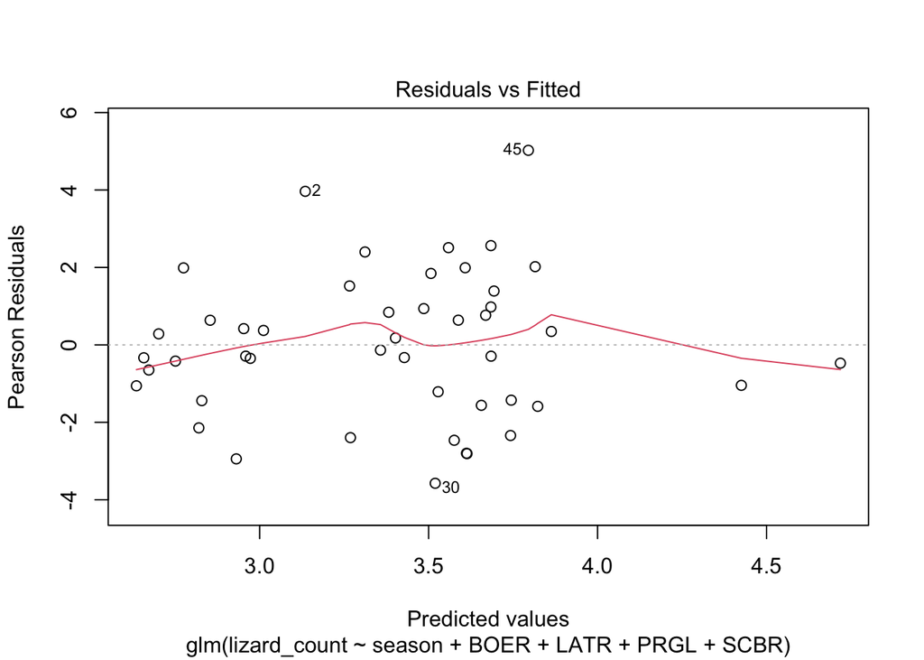

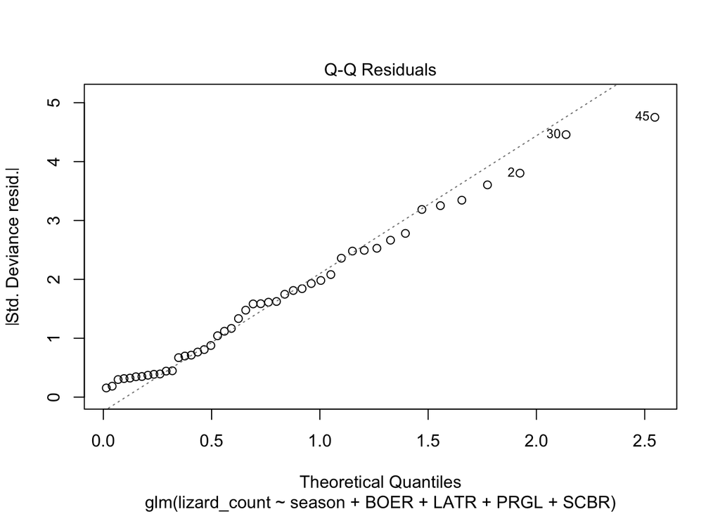

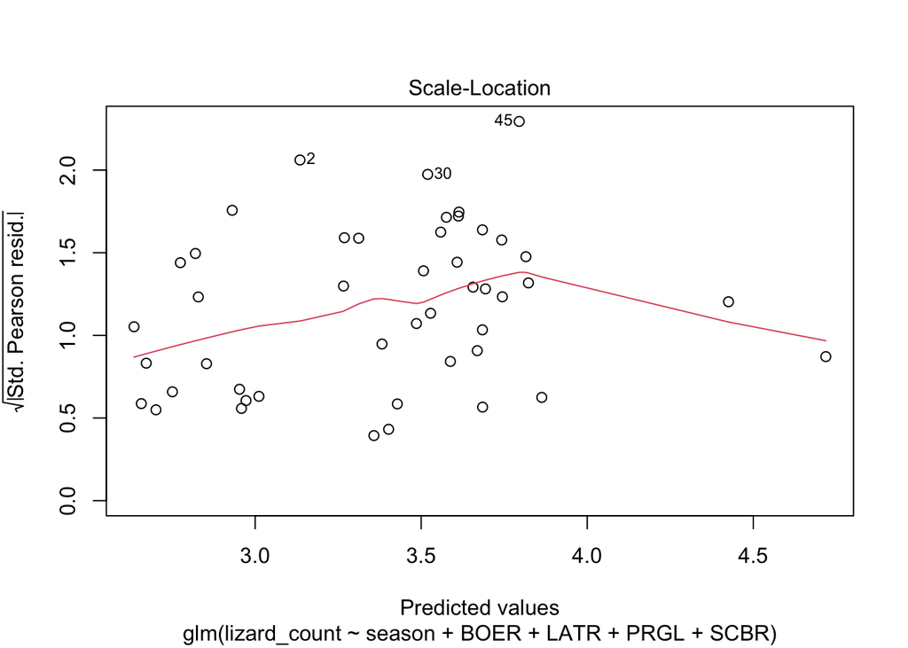

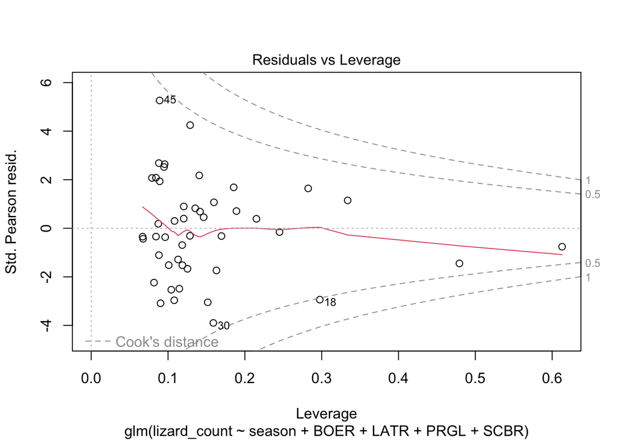

```r
plot(lizard2_mod_2)
```

```r
lizards2_3 <- lizards2_2[-c(18),]

lizard2_mod_3 <- glm(lizard_count~season+BOER+LATR+PRGL+SCBR,
                 data=lizards2_3,
                 family = "poisson")

summary(lizard2_mod_3)
```

```
##
## Call:
## glm(formula = lizard_count ~ season + BOER + LATR + PRGL + SCBR,
##     family = "poisson", data = lizards2_3)
##
## Coefficients:
##             Estimate Std. Error z value Pr(>|z|)
## (Intercept)  3.44840    0.19236  17.927  < 2e-16 ***
## seasonS     -0.91056    0.07600 -11.981  < 2e-16 ***
## seasonW      0.01700    0.08794   0.193 0.846672
## BOER        -0.12535    0.03304  -3.794 0.000148 ***
## LATR         0.06150    0.10972   0.561 0.575104
## PRGL         0.09001    0.05732   1.570 0.116367
## SCBR         0.48990    0.04662  10.509  < 2e-16 ***
## ---
## Signif. codes:  0 '***' 0.001 '**' 0.01 '*' 0.05 '.' 0.1 ' ' 1
##
## (Dispersion parameter for poisson family taken to be 1)
##
##     Null deviance: 502.98  on 44  degrees of freedom
## Residual deviance: 150.83  on 38  degrees of freedom
##   (3 observations deleted due to missingness)
## AIC: 397.22
##
## Number of Fisher Scoring iterations: 4
```